# The goal of *clean code* is to make your code **easy to understand** and **easy to change**.

# Presenter Notes

# Presenter Notes

```
w = x2 - x1
```

# Presenter Notes

```
w = x2 - x1
```

- what are 'w' and 'x'?
  - what do they represent?
  - what are they used for?
- does 'w' stand for 'weight', 'window', 'word', or is it just an arbitrary name for a generic computation?
- what type of data do they hold (e.g. scalar, vector…)?

# Presenter Notes

```
width = x_right - x_left
```

# Presenter Notes

# **1. Use meaningful names**

# Presenter Notes

```
width = x_right - x_left
```

- **[CC1]** give names that **reveal the purpose** of things

# Presenter Notes

```
width = x_right - x_left + 10
```

# Presenter Notes

```
width = x_right - x_left + 10
```

- where does '10' come from?
- what does it represent?
- can I change it?

# Presenter Notes

```
width = x_right - x_left + 2 * padding_x
```

- **[CC1]** replace **magic numbers** with **named constants** or **named parameters**

# Presenter Notes

```
width = (21 - 2 * 1.5) * 0.3937007874
```

- **[CC1]** replace **magic numbers** with named constants or named parameters

# Presenter Notes

```
INCHES_PER_CENTIMETER = 0.3937007874
# ...
width = (21 - 2 * 1.5) * INCHES_PER_CENTIMETER
```

- **[CC1]** replace magic numbers with **named constants** or named parameters

# Presenter Notes

```
INCHES_PER_CENTIMETER = 0.3937007874
# ...
def get_content_width(page_width_cm=21.0, page_margin_cm=1.5):
    content_width_cm = (page_width_cm - 2 * page_margin_cm)
    content_width_inches = content_width_cm * INCHES_PER_CENTIMETER
    return content_width_inches
```

- **[CC1]** replace magic numbers with named constants or **named parameters**

# Presenter Notes

```
check_divisible(a, b)
```

What do you expect this will do?

# Presenter Notes

```
check_divisible(a, b)
```

What do you expect this will do?

- **[CC1] function names should say what they do**

# Presenter Notes

```
def check_divisible(n, divisor):
    if (n % divisor == 0):
        print(n, ' is divisible by ', divisor)
```

**misleading**: I don't expect "something that checks" to print anything

# Presenter Notes

a more accurate name:

```
def print_if_divisible(n, divisor):
    if (n % divisor == 0):
        print(n, ' is divisible by ', divisor)
```

**[CC1] function names should describe side-effects** (such as printing to the console)

# Presenter Notes

```
remove(list, i)
```

# Presenter Notes

```
remove(list, i)
```

**ambiguous**:

- are we removing the element(s) in `list` whose value is equal to `i`?
- or are we removing the element at index `i`?

# Presenter Notes

```
remove_list_element_at_index(list, i)
```

- **[CC1] choose unambiguous names**

# Presenter Notes

```
remove_list_element_at_index(list, i)
```

- **[CC1] choose unambiguous names**
- **clarity at the point of use** is more important than brevity
- include all the words needed to avoid ambiguity from the perspective of the one calling the function
- a general naming template: **`verb_keywords`** (the verb indicates what the function does, the keywords what parameters are expected)

# Presenter Notes

```
add_number(a , b)
add_list(c, d)
```

What do you expect these will do?

# Presenter Notes

```
def add_number(a , b):
    return a + b

def add_list(l, e):
    l.append(e)
```

**confusing**:

- in the first case, `add` calculates the addition
- in the second case, `add` inserts an element
- in the first case, `add` has no side effects, in the second, it does!

# Presenter Notes

```
def add_numbers(a , b):
    return a + b

def append_element_to_list(e, l):
    l.append(e)
```

- **[CC1] use different words for different concepts**

# Presenter Notes

```
distance(couple_1, couple_2)
```

# Presenter Notes

```
distance(couple_1, couple_2)
```

**unclear**:

- what kind of distance is this? distance in what space?
- what do the couples represent?
- a couple could stand for many things: a 2D point, an interval, a rational number, a complex number...

# Presenter Notes

```
distance(couple_1, couple_2)
```

- **problem:** we are **mixing two levels of abstraction**
  - level 1: the space of objects in which a distance can be measured
  - level 2: the implementation of these objects as couples

# Presenter Notes

```
distance(point_1, point_2)
```

- **[CC1] use the appropriate level of abstraction**

# Presenter Notes

```
distance_between_points(point_1, point_2)
distance_between_intervals(interval_1, interval_2)
```

- **[CC1] use the appropriate level of abstraction**
- if several kinds of distance can be used, it is necessary to disambiguate in the function name which kind of distance is computed.

# Presenter Notes

```
def print_if_divisible(n, divisor):
    if (n % divisor == 0):
        print(n, ' is divisible by ', divisor)
```

# Presenter Notes

```
def print_if_divisible(n, divisor):
    if (n % divisor == 0):
        print(n, ' is divisible by ', divisor)
```

- this function does two things:
  - calculating whether an integer is divisible by another
  - printing conditionally on the result

# Presenter Notes

```
def print_if_divisible(n, divisor):
    if (n % divisor == 0):
        print(n, ' is divisible by ', divisor)
```

- this function does two things:
  - calculating whether an integer is divisible by another
  - printing conditionally on the result
- these are two conceptually distinct things. there is no good reason for them to be in the same function.

# Presenter Notes

```
def is_divisible(n, divisor):
    return (n % divisor == 0)
```

- **functions should do one thing**

# Presenter Notes

# **2. Create functions that do one thing**

# Presenter Notes

Example from a past student

# Presenter Notes

[figure not shown]

# Presenter Notes

- what does `display_dots_sparsity_cong` do?
- do you find it easy to understand?
- how would you make it easier to understand?

# Presenter Notes

[figure not shown]

# Presenter Notes

- do you find it easier to understand?

# Presenter Notes

- a lot of programming is about **building abstractions**
- abstractions help you reason about your program and control its intellectual complexity
- top-down: break the function down into simpler ones
- bottom-up: chunk a combination of operations in one function (which you manipulate as one conceptual unit)

# Presenter Notes

# **3.** [Wait for it]

# Presenter Notes

Example from a past student

# Presenter Notes

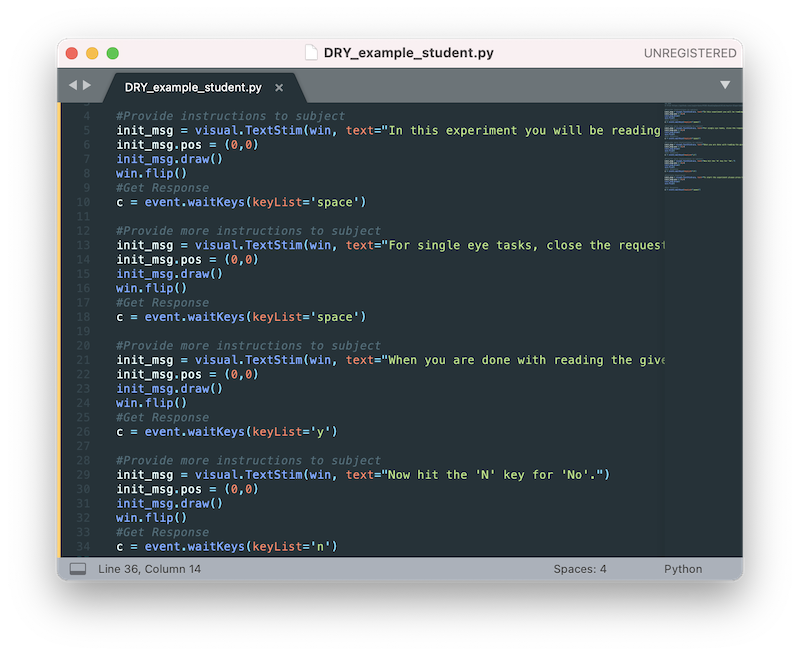

# Presenter Notes

What's wrong?

# Presenter Notes

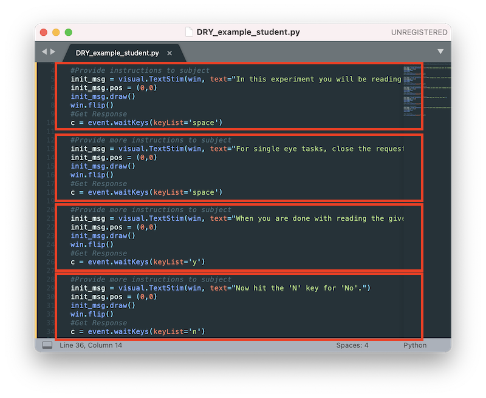

# Presenter Notes

What's wrong?

**Code duplication**

Why is it wrong?

**Hard to change**

# Presenter Notes

# **3. DRY: Don't Repeat Yourself**

# Presenter Notes

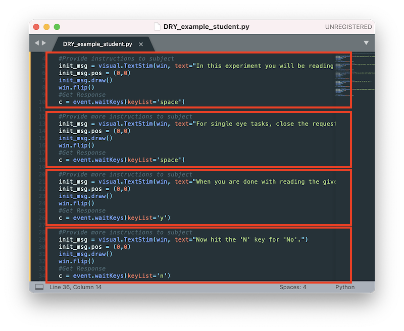

# Presenter Notes

How would you solve this?

# Presenter Notes

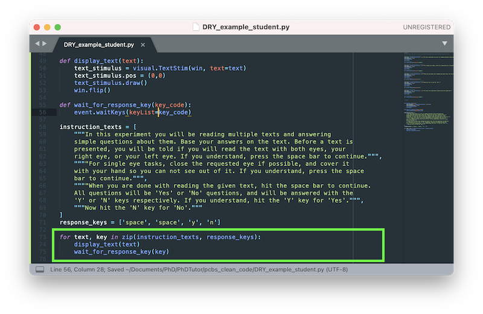

# Presenter Notes

# Presenter Notes

# **4. Explain yourself in code, not comments**

# Presenter Notes

Example from a past student

# Presenter Notes

```
if shuffledtarg_dist[i][1] == 1: ### IF TARGET ###
    # [some code ...]
elif shuffledtarg_dist[i][1] == 0: ### IF DISTRACTOR ###
    # [some other code ...]
```

# Presenter Notes

```
if shuffledtarg_dist[i][1] == 1: ### IF TARGET ###
    # [some code ...]
elif shuffledtarg_dist[i][1] == 0: ### IF DISTRACTOR ###
    # [some other code ...]
```

- why do we need such comments next to `if` and `elif`?
- good intentions, but bad approach
- **[CC4] comments do not make up for bad code**

# Presenter Notes

```
if stimulus_type == STIMULUS_TYPE_TARGET:
    # [some code ...]
elif stimulus_type == STIMULUS_TYPE_DISTRACTOR:
    # [some other code ...]
```

- **clear and expressive code** with few comments is superior to obscure code with lots of comments
- can we do even better?

# Presenter Notes

```
if is_target(stimulus):
    # [some code ...]
elif is_distractor(stimulus):
    # [some other code ...]
```

- **clear and expressive code** with few comments is superior to obscure code with lots of comments
- does this need any comments?

# Presenter Notes

Example from a past student

# Presenter Notes

```
def distance_points(couple1,couple2):
    """Fonction controllant la distance entre nos points
    pour notre ensemble de points aléatoires"""
    return math.sqrt((couple1[0]-couple2[0])**2+(couple1[1]-couple2[1])**2)
```

# Presenter Notes

```
def distance_points(couple1,couple2):
    """Fonction controllant la distance entre nos points
    pour notre ensemble de points aléatoires"""
    return math.sqrt((couple1[0]-couple2[0])**2+(couple1[1]-couple2[1])**2)
```

- **Misleading comment**. It does not accurately describe what the function does.

# Presenter Notes

```
def distance_between_points(point_1, point_2)
```

- Does this need any comments?

# Presenter Notes

Example from a past student

# Presenter Notes

```
exp = design.Experiment("Task") #create and name new exp object
```

- Redundant comment. This is just noise.

# Presenter Notes

# Recap: Cheat sheet

# Presenter Notes

**1. Use meaningful names**. Reveal purpose. Replace magic numbers. Say what functions do. Describe side-effects. Remove ambiguity. Use different words for different concepts. Use the appropriate level of abstraction

**2. Create functions that do one thing**. Build abstractions.

**3. DRY: Don't Repeat Yourself**. Avoid code duplication.

**4. Explain yourself in code, not comments**. Comments do not make up for bad code.